# 死海古卷的洞穴档案 探索性可视化

TidyTuesday · 2026-09-15 (Week 37)

作者

zlZayn

发布于

2026年9月20日

# 洞穴档案：771 份库姆兰手稿

## 洞穴编号只对库姆兰成立

`dead_sea_scrolls.csv` 是 809 行 × 18 列，`manuscript_id` 无重复。**`cave` 不是全局唯一的洞穴编号**：只有 `site_parent = Qumran` 的 771 行带洞穴号，其余 38 行（Masada 12、Nahal Hever 16、Wadi Murabba’at 10）的 cave 全部为空。Masada 的编号与库姆兰的洞穴号不同源，混进一张矩阵就是口径错误，所以本页三张图统一只用库姆兰子集。

另一条可核对的一致性：`site` 字符串（`Qumran, Cave 4` 这类）里的数字与 `cave` 列**逐行一致，不一致 0 行**——所以 cave 不是随手填的标签，可以当编号用。库姆兰实际用到 10 个洞穴：1、2、3、4、5、6、7、8、9、11；10 号洞在数据里不存在（不是缺测，是这批藏品里没有）。

表 1: cave 列的适用范围：只有库姆兰的藏品带洞穴编号

| site_parent | cave 有编号 | cave 为 NA | 合计 |
| --- | --- | --- | --- |
| Qumran | 771 | 0 | 771 |
| Masada | 0 | 12 | 12 |
| Wadi Murabba'at | 0 | 10 | 10 |
| Nahal Hever | 0 | 16 | 16 |

## 入图样本：口径链与三处再编码

本周的口径链只有一行，正文与三张图的图注共用它：

> raw 809 -> plotted 771 (38 份 Masada / Nahal Hever / Wadi Murabba’at 藏品没有库姆兰洞穴编号)

**剔除原因只有一个**：非库姆兰藏品在 `cave` 上是 NA（上文已断言），不是随机缺失，也不是把 `num_images = 0` 当缺失。入图的 771 份手稿里 `num_images` 一个 NA 都没有，其中 4 份是**有记录但为 0 张图**——0 是观测值，本页不剔除也不填补（全表 0 张图共 6 份，另 2 份在 Masada）。

三处再编码写在这里，正文与图注口径一致：

[output not shown]

## 图 1｜洞穴 × 阶段：一个洞吃掉七成档案

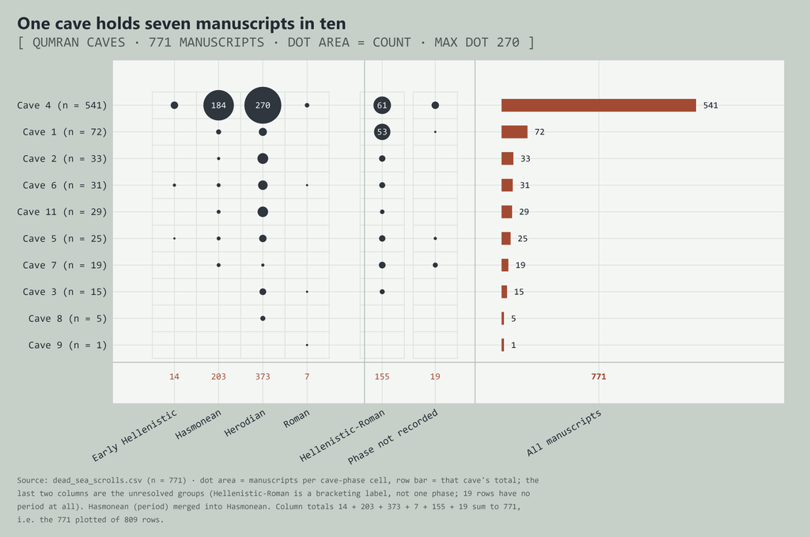

图 1: Cave 4 holds seven manuscripts in ten; the Herodian phase alone accounts for nearly half of the Qumran archive.

**读数**：771 份手稿里 541 份在 4 号洞（70.2%），373 份属希律时期（48.4%）；矩阵里最大的一格是 **Herodian 期的 Cave 4，270 份**。

轴上要留一个口径余地：`Hellenistic-Roman` 是**跨希腊化到罗马的括注标签**，不指向某一期，因此它与 `Early Hellenistic`/`Hasmonean`/`Herodian`/`Roman` 四列**不是互斥时间轴**（174 行落在两个未解析分组里，其中 19 行根本没有 `period`）。所以我不按列讲”时期趋势”，只讲同一行内的分布。

表 2: 图 1 的原始数字（与图上同一份聚合；行序、列序与图一致，末行末列可互相验算）

| 洞穴 | Early Hellenistic | Hasmonean | Herodian | Roman | Hellenistic-Roman | Phase not recorded | All |
| --- | --- | --- | --- | --- | --- | --- | --- |
| Cave 4 | 11 | 184 | 270 | 4 | 61 | 11 | 541 |
| Cave 1 | 0 | 5 | 13 | 0 | 53 | 1 | 72 |
| Cave 2 | 0 | 2 | 23 | 0 | 8 | 0 | 33 |
| Cave 6 | 2 | 3 | 18 | 1 | 7 | 0 | 31 |
| Cave 11 | 0 | 3 | 22 | 0 | 4 | 0 | 29 |
| Cave 5 | 1 | 3 | 11 | 0 | 8 | 2 | 25 |
| Cave 7 | 0 | 3 | 2 | 0 | 9 | 5 | 19 |
| Cave 3 | 0 | 0 | 9 | 1 | 5 | 0 | 15 |
| Cave 8 | 0 | 0 | 5 | 0 | 0 | 0 | 5 |
| Cave 9 | 0 | 0 | 0 | 1 | 0 | 0 | 1 |
| 合计 | 14 | 203 | 373 | 7 | 155 | 19 | 771 |

## 图 2｜每洞的类别构成：量大的洞不是专一的洞

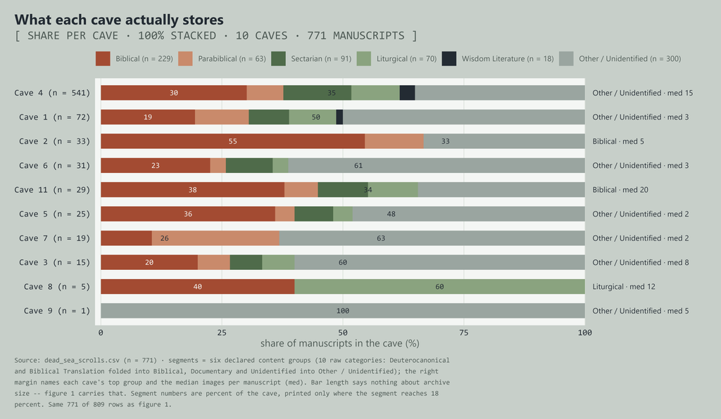

图 2: Composition by cave: Other / Unidentified leads 7; Biblical leads 2; Liturgical leads 1. Every cave is stacked to 100 percent, so bar length never encodes archive size.

**读数**：残差组 `Other / Unidentified` 在 7 个洞里居首，`Biblical` 在 2 个洞里居首，`Liturgical` 只在 1 个洞（8 号洞）居首（`Liturgical` 3 份 vs `Biblical` 2 份，而这个洞只有 5 份手稿，一句话就得小心）。**量最大的洞不等于最专一的洞**：Cave 4 装 541 份手稿，构成是 35% 残差 + 30% 圣经文本 + 14% 教派文献；而 11 号洞（29 份）的圣经文本占 38%，比 Cave 4 高。

**图像数也不听体积的**：Cave 4 每份手稿的图像中位数 15 张，11 号洞 20 张、5 号洞 2 张；89.3% 的图像总量确实压在 Cave 4，但那是总量（23,747 张），不是每份手稿的强度。

表 3: 图 2 的原始数字（列序与图上堆叠顺序一致，可与堆叠条逐段对账）

| 洞穴 | Biblical | Parabiblical | Sectarian | Liturgical | Wisdom Literature | Other / Unidentified | 合计 | 中位图像数 |
| --- | --- | --- | --- | --- | --- | --- | --- | --- |
| Cave 4 | 163 | 41 | 76 | 54 | 17 | 190 | 541 | 15 |
| Cave 1 | 14 | 8 | 6 | 7 | 1 | 36 | 72 | 3 |
| Cave 2 | 18 | 4 | 0 | 0 | 0 | 11 | 33 | 5 |
| Cave 6 | 7 | 1 | 3 | 1 | 0 | 19 | 31 | 3 |
| Cave 11 | 11 | 2 | 3 | 3 | 0 | 10 | 29 | 20 |
| Cave 5 | 9 | 1 | 2 | 1 | 0 | 12 | 25 | 2 |
| Cave 7 | 2 | 5 | 0 | 0 | 0 | 12 | 19 | 2 |
| Cave 3 | 3 | 1 | 1 | 1 | 0 | 9 | 15 | 8 |
| Cave 8 | 2 | 0 | 0 | 3 | 0 | 0 | 5 | 12 |
| Cave 9 | 0 | 0 | 0 | 0 | 0 | 1 | 1 | 5 |

## 图 3｜阶段 → 材质 → 类别：材质这一层几乎不筛内容

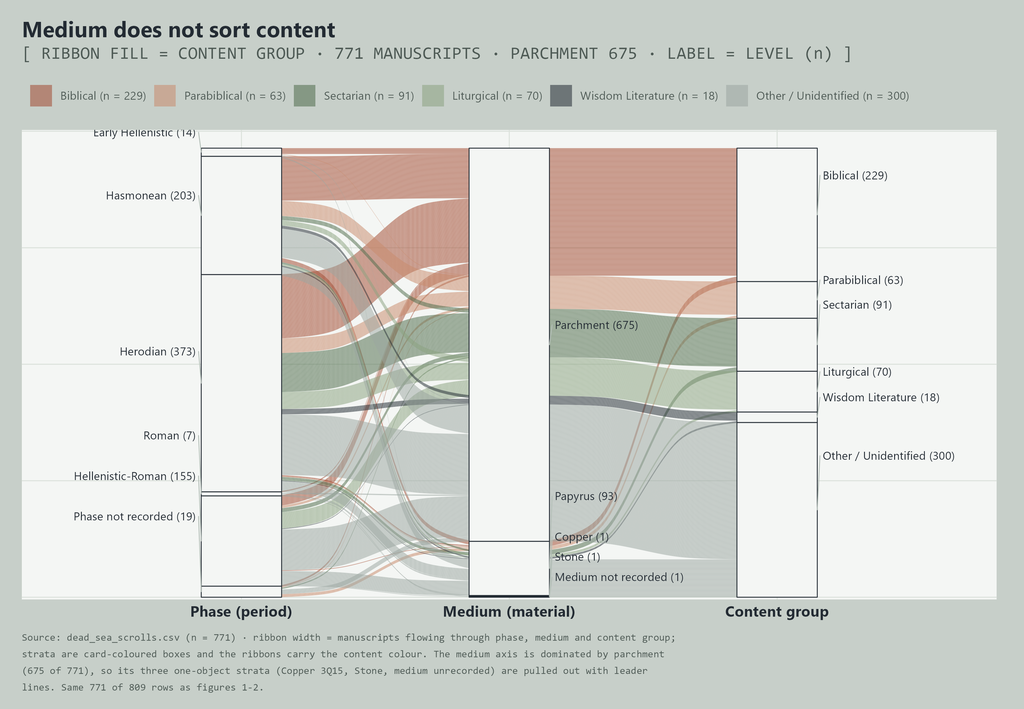

图 3: Parchment carries 87 percent of the archive and feeds all six content groups, so medium does not sort content.

**读数**：675 份是羊皮纸、93 份是纸草，其余三种材质各 1 份（铜、石、材质字段为空）；羊皮纸这一种材质就覆盖了全部 6 个内容组，所以材质这一层筛不出内容。真正有落差的是阶段：36 个 阶段 × 类别 格子里有 9 个是 0，而且**全部**落在 `Early Hellenistic` / `Roman` / `Phase not recorded` 三行（三行合计 40 份，占 5.2%）——这三行读不出类别偏好；反过来 `Herodian` 一行 6 格最少也有 10 份（最大 123 份，Other / Unidentified）。**结论是负面的但有用**：在这份数据里，材质与阶段都不能预测内容类别，能预测内容类别的是洞穴（图 1、图 2）。

## 数据异常（记录，不改数据）

| 现象 | 原始数字 | 处理 |
| --- | --- | --- |
| `Hasmonean (period)` 与 `Hasmonean` 并列 | 1 行（4Q400） | 图上并入 `Hasmonean`，正文与图注写明 |
| `Hellenistic-Roman` 是跨期括注 | 155 行 | 独立成列并加分隔线，不参与时间趋势叙述 |
| `period` 为空 | 24 行（其中库姆兰 19 行） | 单独一列 `Phase not recorded`，不当缺失剔除 |
| `material` 为空 | 1 行（4Q556） | 图 3 记为 `Medium not recorded` |
| `num_images = 0` | 库姆兰 4 份（1Q71、1Q72、3Q15、5Q10）+ Masada 2 份 | 当观测值保留；铜卷 3Q15 是唯一 0 张图的非纸草藏品 |
| `num_images` 极端值 | 最大 728 张（4Q502，Other Non-biblical）；全表中位数 11 张 | 不剔除、不截断；图 2 用中位数而非均值 |
| 洞穴编号不连续 | 用到 1、2、3、4、5、6、7、8、9、11，缺 10 | 不补齐空行，矩阵只画实际存在的洞 |

非库姆兰的 38 份藏品没有进入任何一张图，这里补一张表交代它们是什么：

表 4: 未入图的 38 份藏品：分布在 3 个遗址群，cave 全部为 NA

| site_parent | site | 藏品数 | 图像总数 | 图像中位数 |
| --- | --- | --- | --- | --- |
| Masada | Masada | 12 | 34 | 2.0 |
| Nahal Hever | Unknown Cave | 12 | 94 | 4.5 |
| Wadi Murabba'at | Wadi Murabba'at | 10 | 52 | 3.0 |
| Nahal Hever | Cave of Horror | 4 | 140 | 12.0 |

## 方法与口径

| 项 | 值 |
| --- | --- |
| 数据 | `data/dead_sea_scrolls.csv`（809 × 18，`manuscript_id` 唯一） |
| 入图样本 | raw 809 -> plotted 771 (38 份 Masada / Nahal Hever / Wadi Murabba’at 藏品没有库姆兰洞穴编号) |
| 三图共用 | 同一批 771 份手稿、同一套 6 组类别与颜色、同一套洞穴顺序（按手稿数降序） |
| `cave` 口径 | 仅在 `site_parent == "Qumran"` 时存在；与 `site` 字符串中的编号逐行一致（不一致 0 行） |
| `period` 口径 | 7 种取值 → 6 列（`Hasmonean (period)` 并入 `Hasmonean`，`NA` 单独成列）；`Hellenistic-Roman` 为跨期标签，与前四列不互斥 |
| `content_category` 口径 | 10 类 → 6 组；三张图共用同一分组，图例标签带 n |
| 数字来源 | 正文所有数字来自本页 prep chunk 的同一份聚合，图 1/2 的表可与图上逐格对账；内联数字一律经 `sprintf`/`format` 定型，避开 knitr 对大数的科学计数法改写 |
| 不画的东西 | 非库姆兰遗址不并入洞穴矩阵；不画时间趋势（`Hellenistic-Roman` 与两个未解析分组使列非互斥）；`num_images` 不做对数轴或截断 |